# FINAL PROJECT: HIGH DIMENSIONAL ANALYSIS

Members:

- 19110348: Đỗ Khánh Đăng Khoa
- 19110522: Bùi Thị Thanh Xuân
- 19110414: Võ Hoàng Phúc

```python
#import library
import torch
import torch.nn as nn
import torch.optim as optim
import torch.nn.functional as F
from torch.autograd import Variable as V

import matplotlib
import pandas as pd
import numpy as np
import matplotlib.pylab as plt
from matplotlib import cm

import seaborn as sns
from sklearn.metrics import accuracy_score, rand_score, silhouette_score,davies_bouldin_score
from sklearn.utils import shuffle
from sklearn.preprocessing import StandardScaler
from sklearn.cluster import KMeans, SpectralClustering, AgglomerativeClustering
from sklearn.decomposition import PCA, KernelPCA, FastICA
from sklearn.manifold import TSNE
from sklearn.preprocessing import StandardScaler as scale

from scipy.spatial.distance import cdist
from scipy.spatial import distance
import random

import glob
import os
from scipy.linalg import eigh
from scipy.spatial.distance import pdist, squareform
from scipy import exp
from mpl_toolkits.mplot3d import Axes3D
import time

matplotlib.style.use('ggplot')
%matplotlib inline
```

```python
# Mount drive
from google.colab import drive
drive.mount('/content/gdrive')
```

```python
# Path data
root = "/content/gdrive/MyDrive/XLĐC/HMP_Dataset/"
checkPath = os.path.isdir(root)
print("The path and file are valid or not :", checkPath)
```

```
The path and file are valid or not : True
```

# READ LABEL AND DATASET

```python
# Class label identify
dict_wrist = {'Brush_teeth':0, 'Climb_stairs':1, 'Comb_hair':2, 'Descend_stairs':3, 'Drink_glass':4,
              'Eat_meat':5,'Eat_soup':6,'Getup_bed':7,'Liedown_bed':8,'Pour_water':9,'Sitdown_chair':10,
              'Standup_chair':11,'Use_telephone':12,'Walk':13 }

# Read file for al class
def read_file(dict_wrist):
    '''
        Hàm đọc file
        -----------------
        Tham số:
            class_dict: một dictionary chứa 14 hành động được gán nhãn từ 0 đến 13
        -----------------
        Trả về:
            X: một list có len = 14 chứa dữ liệu đã được đọc (Mỗi phần tử của list có dạng numpy array chứa các sample của nhãn đó)
    '''
    X = []
    for c in dict_wrist.keys():
        f = glob.glob(root + c + '/*')
        d = read_each_file(f, cls=c)
        X.append(d)
    return X #type list

# Read file by class
def read_each_file(files, cls):
    temp = []
    for f in files:
        data = pd.read_table(f, sep=' ', header=None)
        data = np.array(data)
        temp.append(data)
    return temp

# Data processing: split features and their corresponding labels into proper format
def prepare_data(data):
    '''
        Hàm tách features và labels
        ---------------------------
        Tham số:
            data: list chứa các dữ liệu vừa được đọc
         ---------------------------------------------
        idx| size | value                            |
        ----------------------------------------------
        0  |  12  | (2167,3), (844,3), ...           |
        ----------------------------------------------
        1  | 102  | (270,3) , (270,3), ...           |
        ----------------------------------------------
        2  |  31  | ...                              |
        ----------------------------------------------
        3  |  42  | ...                              |
        ----------------------------------------------
        .  | ...  |
        .  | ...  | ...                              |
        .  | ...  |
        ----------------------------------------------
        13 | 100  | (1170,3), (956,3)                |
        ----------------------------------------------
        Trả về:
            X: list có chiều dài là 839, tương ứng 839 samples
            y: 839 labels
    '''
    X = []
    y = []
    for i,f in enumerate(data):
        for ii in f:
            X.append(ii)
            y.append(i)
    return X, y
```

```python
# Read ADL dataset
temp_X = read_file(dict_wrist)
X,original_label = prepare_data(temp_X)
```

# PREPROCESSING DATA

Mô tả dữ liệu:

- X có 839 samples
- Mỗi sample là kx3 (k không cố định)
- Từng sample có 3 cột (hay features của từng sample): x,y,z

Bước 1: Padding data

- Tìm giá trị k (max_value) mà lớn nhất trong kx3 samples
- Lấy dòng cuối cùng trong từng sample đắp vào cho đủ (max_value)x3: cụ thể trong bài là (9318x3)
- Cuối cùng chúng ta sẽ được 839 samples với từng sample là 9318x3

Bước 2: Chuyển từng sample thành vector k chiều, tức trong bài là vector 9318x3 chiều

- Cuối cùng dữ liệu của chúng ta có được là một numpy array: (839x27954)

Chi tiết:

Bước 1: Padding data

```python
# Define padding function
def padding(X):
    '''
        Hàm padding
        --------------
        Tham số:

            X: một list có chiều dài 839, mỗi phần tử là một numpy array có dạng (k,3)
        ----------------------
        idx |   size (k,3)   |
        ----------------------
        0   |  (2167,3)      |
        ----------------------
        1   |  (844,3)       |
        ----------------------
        2   |  (2228,3)      |
        ----------------------
        3   | ...            |
        ----------------------
        .   | ...            |
        .   | ...            |
        ----------------------
        838 |  (1050,3)      |
        ----------------------
        Trả về:
            X: list có chiều dài 839, mỗi phần tử là một nummpy array có dạng (9318,3)

    '''
    #Tìm giá trị k lớn nhất (kx3)
    max=0
    for i in X:
        if i.shape[0] > max:
            max = i.shape[0]

    # Padding
    for i in range(len(X)):
        if X[i].shape[0] < max:
            temp = X[i][X[i].shape[0]-1]
            temp = np.tile(temp, (max-X[i].shape[0], 1))
            X[i] = np.append(X[i],temp,axis= 0)
    return X
```

```python
# Apply padding in ADL dataset
X_padding = padding(X)
```

Bước 2: Chuyển từng sample thành vector k chiều, tức trong bài là vector 9318x3 chiều:

```python
# Define vectorization
def vectorization(X):
    '''
    Hàm Chuyển từng sample thành vector max_value (9318x3) chiều
    ---------------------------------------------------
    Tham số:
        X: list có chiều dài 839, mỗi phần tử là một nummpy array có dạng (9318,3)
        ----------------------
        idx |   size(9318,3) |
        ----------------------
        0   |  (9318,3)      |
        ----------------------
        1   |  (9318,3)      |
        ----------------------
        2   |  (9318,3)      |
        ----------------------
        3   | ...            |
        ----------------------
        .   | ...            |
        .   | ...            |
        ----------------------
        838 |  (9318,3)      |
        ------------------------------------------------
    Trả về:
        X: list có chiều dài 839, mỗi phần tử là một nummpy array có dạng (9318x3,)
        ----------------------
        idx |   size(27954,) |
        ----------------------
        0   |  (27954,)      |
        ----------------------
        1   |  (27954,)      |
        ----------------------
        2   |  (27954,)      |
        ----------------------
        3   | ...            |
        ----------------------
        .   | ...            |
        .   | ...            |
        ----------------------
        838 |  (27954,)      |
        ----------------------
    '''
    for i in range(len(X)):
        X[i] = X[i].flatten()
    return X
```

```python
# Apply vectorization on padded ADL data
X_vector = vectorization(X_padding)

# To numpy array
features = np.array(X_vector)
original_label = np.array(original_label)

#Print shape of features and original_label
print(features.shape)
print(original_label.shape)
```

```
(839, 27954)
(839,)
```

Implement Kmeans clustering step by step:

```python
# Define euclidean distancce metric
def euclidean_dist(X,centroids):
    #Calculate euclidean_distance
    return distance.cdist(X, centroids, 'euclidean')

# Update new centroid in kmeans algorithm
def update_new_centroid(X,new_labels,K):
    #Update centroids
    return np.array([X[new_labels == k].mean(axis=0) for k in range(K)])

# check convergence function
def has_converge(centers, new_centers):
    # return True if two sets of centers are the same
    return (set([tuple(a) for a in centers]) ==
        set([tuple(a) for a in new_centers]))

# Define Kmeans clusturing algorithm
def Kmeans_Clustering(X,K):

    #Convert data to numpy array
    if type(X) != np.ndarray:
        X = X.to_numpy()

    # randomly pick k rows of X as initial centers
    k_initial = np.random.choice(len(X), K ,replace = False)
    centroids = [X[k_initial,:]]
    label = []
    it = 0
    while 1:

        Dist = euclidean_dist(X,centroids[-1]) #Calculate euclidean_distance
        new_labels = np.argmin(Dist,axis=1)   #assign new labels
        label.append(new_labels)

        #Update centroids
        new_centroids = update_new_centroid(X,new_labels,K)
        #Check converge
        if has_converge(centroids[-1], new_centroids):
            break
        centroids.append(new_centroids)
        it += 1
    return label
```

# Kmeans with padding data

```python
# Apply Kmeans cluster on padded ADL data
label = Kmeans_Clustering(features,14)
y_label  = label[-1]
```

```python
# Compute evaluation metrics to verify effectiveness of cluster method using padded features

# Start checking time spent for testing Kmeans use padded features
time_start = time.time()

#Accuracy
y_data_accuracy = accuracy_score(original_label,y_label)

#rand_score
y_data_rand_score = rand_score(original_label,y_label)

#silhouette_score
y_data_silhouette_score = silhouette_score(features, y_label,
                                           metric = "euclidean", sample_size= 839)

#benchmark
score_table = pd.DataFrame.from_dict({'accuracy_score': [y_data_accuracy], 'rand_score': [y_data_rand_score],
                              'silhouette_score': [y_data_silhouette_score]}, orient='index',
                              columns=['score'])


# End checking time spent for testing Kmeans use padded features
time_padding = time.time() - time_start
print('Kmean with padding done! Time elapsed: {} seconds'.format(time_padding))

print(score_table)
```

```
Kmean with padding done! Time elapsed: 1.4720978736877441 seconds
                     score
accuracy_score    0.084625
rand_score        0.852740
silhouette_score  0.190629
```

Sự khác nhau giữa các metric:

- accuracy_score:

  Trong bài toán phân loại đa nhãn, hàm này tính toán độ chính xác của tập hợp con: tập hợp nhãn được dự đoán cho một mẫu phải khớp chính xác với tập nhãn tương ứng trong y_true.
- rand_score:

  Chỉ số Rand tính toán độ đo tương tự giữa hai cụm bằng cách xem xét tất cả các cặp mẫu và đếm các cặp được chỉ định trong các cụm giống nhau hoặc khác nhau trong cụm được dự đoán và đúng.

  The raw RI score is:

  RI = (number of agreeing pairs) / (number of pairs)
- silhouette_score:

  Hệ số Silhouette được tính bằng cách sử dụng khoảng cách trung bình trong cụm ( a) và khoảng cách trung bình trong cụm gần nhất ( b) cho mỗi mẫu.

  Giá trị tốt nhất là 1 và giá trị kém nhất là -1. Các giá trị gần 0 cho biết các cụm chồng chéo. Các giá trị âm thường chỉ ra rằng một mẫu đã được chỉ định sai cụm, vì một cụm khác giống nhau hơn.

*Nhận xét:*

Qua Kmeans phân cụm trên tập dữ liệu đã padding và kiểm tra với các độ đo khác nhau chúng ta thấy:

- accuracy_score cho kết quả không tốt (0.084625) trên miền accuracy [0,1]. Điều này cho thấy đặc trưng padding không tốt cho khía cạnh phân lớp.
- rand_score biểu diễn sự khoảng cách giữa các cụm. Khoảng cách càng xa thì rand_score càng nhỏ và khi rand_score nhỏ thì kết quả phân cụm mới đủ tốt. Tuy nhiên, với đặc trưng padding, rand_score lại cho kết quả ngược lại (0.852740), điều này cho thấy các cụm phân được bằng đặc trưng padding là gần nhau và không tốt cho quá trình phân cụm.
- silhouette_score có miền giá trị là [-1,1], biểu diễn khả năng 1 điểm dữ liệu có được phân cụm đúng hay không. Với đặc trưng padding, kết quả thu được là (0.190629). Độ tốt với khía cạnh phân cụm điểm dữ liệu là ở mức trung bình. -> Kết luận: kết quả tính toán của phân cụm dữ liệu qua phương pháp padding cho kết quả kém ở 2 trên 3 độ đo. Điều này cho thấy đặc trưng padding không tốt với bài toán phân cụm với dữ liệu dạng chuỗi(timeseries).

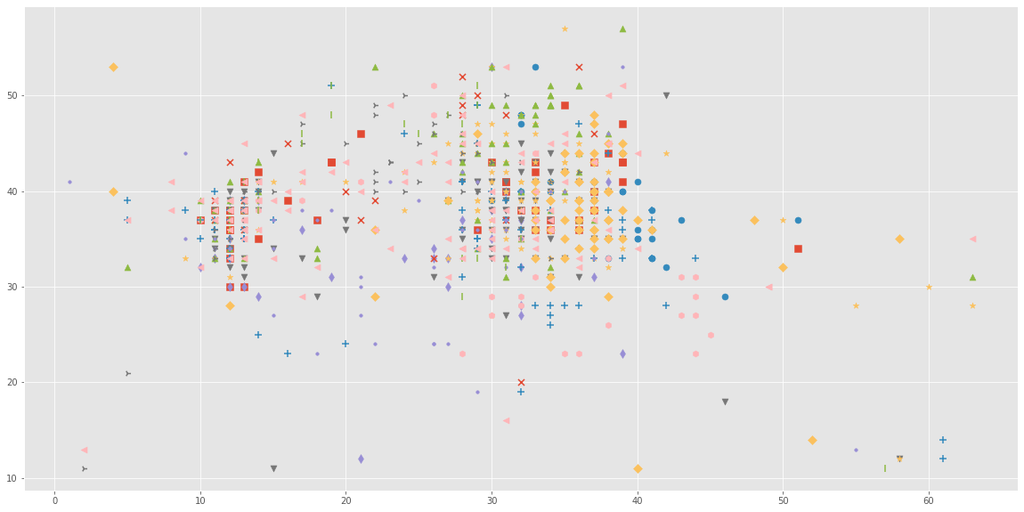

```python
# Visualization after using kmeans clutering
def data_visualization(X,y_pred):
    markers = ["s","o","d","v","*","^","h","x","+",".","4","D","|","<"]
    plt.figure(figsize=(20,10))
    for ii in range(14):
        plt.scatter(X[:,0][y_pred==ii], X[:,1][y_pred==ii],cmap='Set2',marker=markers[ii],s=50)
data_visualization(features,y_label)
```

Nhìn hình ta thấy dữ liệu vẫn còn chồng chất, chưa được phân cụm rõ ràng.

# Dimensionality reduction using PCA

```python
#shuffle data
wrist_X, wrist_Y = shuffle(features,original_label, random_state=0)
```

```python
# Start checking time spent for extracting PCA features
time_start = time.time()

# Apply PCA on extracting dimensional reduced features
pca = PCA(n_components=3)
pca_result = pca.fit_transform(wrist_X)

# End checking time spent for extracting PCA features
time_pca = time.time() - time_start
print('PCA done! Time elapsed: {} seconds'.format(time_pca))

#Projected
projected_1 = pca_result[:,0]
projected_2 = pca_result[:,1]
projected_3 = pca_result[:,2]
res = pd.DataFrame(projected_1, columns=['PC1'])
res['PC2'] = projected_2
res['PC3'] = projected_3
res['label'] = wrist_Y

print('Explained variation per principal component: {}'.format(pca.explained_variance_ratio_))
```

[output not shown]

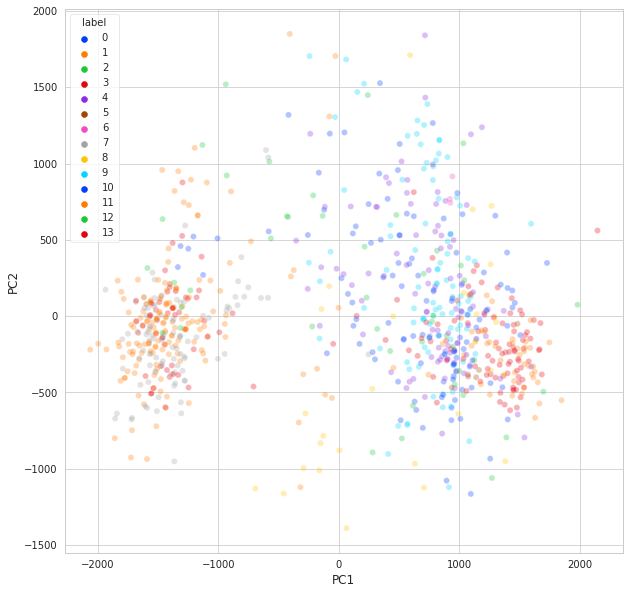

```python
# Visualization for PCA (2D Visualization)
sns.set_style("whitegrid")
plt.figure(figsize=(10,10))
sns.scatterplot(
    x="PC1", y="PC2",
    hue="label",
    data= res,
    palette = sns.color_palette("bright",14),
    legend="full",
    alpha=0.3
)
```

Số lượng thông tin giữ được của 3 PC đầu đã khá cao (khoảng 93%), nhưng dữ liệu vẫn chồng chất lên nhau trong 2 chiều.

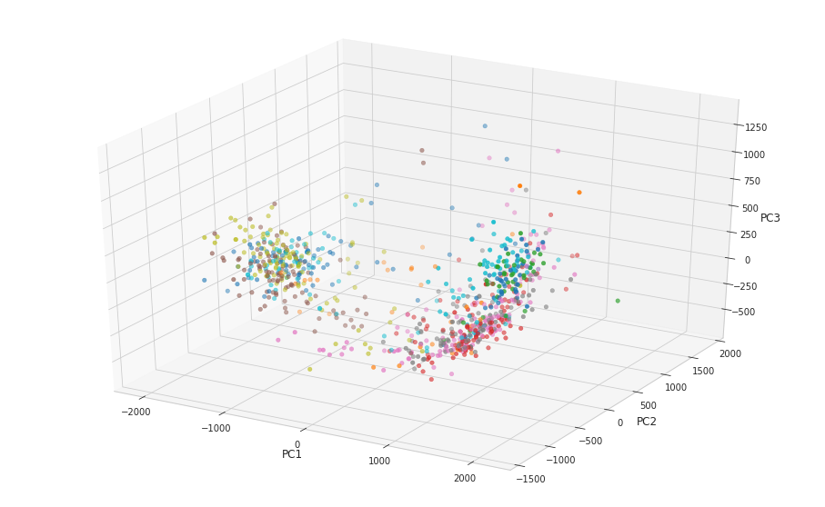

```python
# Visualization for PCA (3D Visualization)
ax = plt.figure(figsize=(16,10)).gca(projection='3d')
ax.scatter(
    xs=res["PC1"],
    ys=res["PC2"],
    zs=res["PC3"],
    c=res["label"],
    cmap='tab10'
)
ax.set_xlabel('PC1')
ax.set_ylabel('PC2')
ax.set_zlabel('PC3')
plt.show()
```

## Kmeans after using PCA

```python
# Kmeans with sklearn

# Train
kmean_pca = KMeans(n_clusters=14).fit(pca_result)

# Predict
clusters_pca = kmean_pca.predict(pca_result)
```

```python
# Compute evaluation metrics to verify effectiveness of cluster method using  PCA features

# Accuracy
y_pca_accuracy = accuracy_score(wrist_Y,clusters_pca)

# rand_score
y_pca_rand_score = rand_score(wrist_Y,clusters_pca)

# silhouette_score
y_pca_silhouette_score = silhouette_score(pca_result, clusters_pca,
                                           metric = "euclidean", sample_size= 839)

#benchmark
score_table = pd.DataFrame.from_dict({'accuracy_score': [y_pca_accuracy], 'rand_score': [y_pca_rand_score],
                              'silhouette_score': [y_pca_silhouette_score]}, orient='index',
                              columns=['score'])
score_table
```

|  | score |
| --- | --- |
| accuracy_score | 0.139452 |
| rand_score | 0.844729 |
| silhouette_score | 0.315015 |

**Nhật xét:**

Khi Kmeans phân cụm dùng đặc trưng PCA trên dữ liệu đã thực hiện phương pháp padding và kiểm định với các độ đo khác nhau chúng ta thấy:

- accuracy_score của đặc trưng đang xét là (0.139452) tốt hơn so với khi dùng kmean trên dữ liệu padding chưa qua giảm số chiều là (0.084625). Tuy nhiên, kết quả vẫn không đủ tốt.
- rand_score của đặc trưng đang xét là (0.844729), tốt hơn so với đặc trưng trên tập dữ liệu padding chưa qua giảm số chiều là (0.852740) (Do chỉ số rand_score càng cao thì độ chồng chéo giữa các cụm càng rõ rệt). Tuy nhiên, kết quả cũng không đủ tốt.
- silhouette_score của đặc trưng đang xét là (0.315015), tốt hơn so với đặc trưng trên tập dữ liệu padding là (0.190629). Tuy nhiên, kết quả cũng chỉ đạt ở mức trung bình khá.
- > Kết luận: kết quả tính toán phân cụm dùng đặc trưng PCA trên dữ liệu đã qua xử lý bằng padding cho kết quả kém ở 2 trên 3 độ đo.

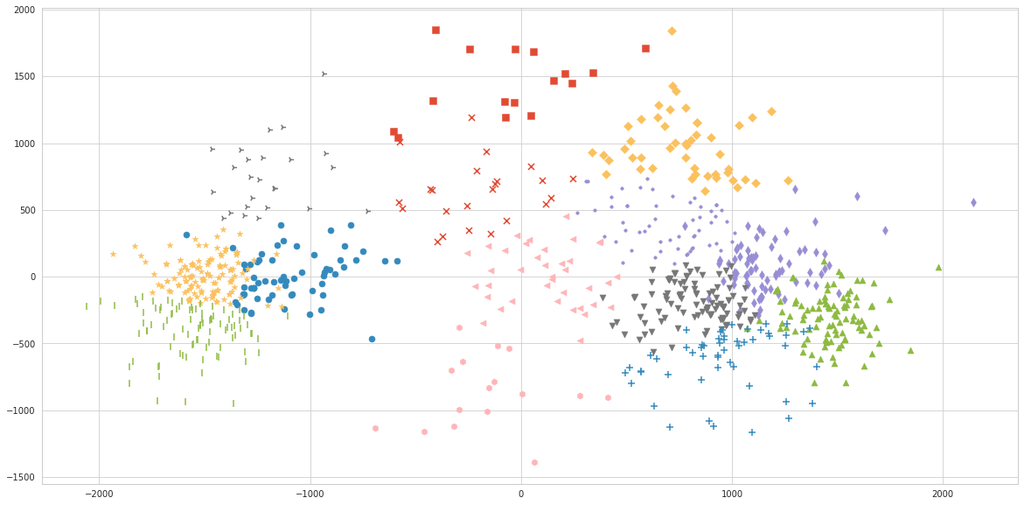

```python
#Visualization after using kmeans clutering
data_visualization(pca_result,clusters_pca)
```

Nhìn hình ta thấy dữ liệu phân cụm khá tốt.